# COSE461 Assignment 1: Word Vectors

### **Due 9:00 AM, Tue Mar 21**

Welcome to COSE461.

## About using Colab

Our assignment will be in the form of Jupyter notebooks to be able to be run in Google Colab. Colab is an online editor that provides free access to a GPU, so you don't have to worry about the computing resources when doing the assignements. GPU can be accessed by `Edit->Notebook settings` or `수정->노트 설정` and choosing GPU in the Hardware accelerator dropdown (We will not be using a GPU in the current assignment, though). To get started, make a copy of the assignment by clicking `File->Save a copy in drive...` or `파일->드라이브에 사본 저장`. You will need to be logged into a Google account, such as your @korea.ac.kr mail account.

The code cells in Colab are executed on a `preemtible` VM instance. This means:

- Every time you open the notebook, you will be assigned a different machine; run cells and files will be lost.
- Even if you keep using a machine attached to notebook, it can be lost and altered with other machine after 24 hours.

Therefore, if you have some output that you don't want to lose, you should download them to your local machine or save them to your Google drive by mounting it to the VM instance. The former can be done by `File->Download` or `파일->다운로드`, where the latter can be done by using something similar to the following code snippet:

```
from google.colab import drive

# mount Google drive
drive.mount('/mnt/')

# You can run a linux command by putting ! at the start
# The following commands shows the number of files in your drive
!echo -e "\n# of files in /mnt/My Drive/:"
!ls -l "/mnt/My Drive/" | wc -l
```

One important limitation to Colab is that it disconnects from VM when is inactive for a few tens of minutes. So you should either check Colab periodically, or use something like [this](https://stackoverflow.com/questions/54057011/google-colab-session-timeout). If you have available computing resources and if you do not want to go through such inconvenience, feel free to use yours by recreating a similar environment to Colab.

# Word vectors

This assignment is based on the Stanford CS224n lecture by Christopher Manning. The followings are the import, data downloading, and unzipping statements. Do not modify, and simply run it once before going down.

```python
!pip install numpy==1.23.5 gensim==4.3.0
```

[output not shown]

```python
from gensim.models import KeyedVectors
from gensim.test.utils import datapath
import pprint
import matplotlib.pyplot as plt
plt.rcParams['figure.figsize'] = [10, 5]
import nltk
nltk.download('reuters')
from nltk.corpus import reuters
import numpy as np
import random
import scipy as sp
from sklearn.decomposition import TruncatedSVD
from sklearn.decomposition import PCA

np.random.seed(0)
random.seed(0)
!unzip -nq /root/nltk_data/corpora/reuters.zip -d /root/nltk_data/corpora
```

Word Vectors are often used as a fundamental component for downstream NLP tasks, e.g. question answering, text generation, translation, etc., so it is important to build some intuitions as to their strengths and weaknesses. Here, you will explore two types of word vectors: those derived from co-occurrence matrices, and those derived via GloVe.

**Note on Terminology**: The terms "word vectors" and "word embeddings" are often used interchangeably. The term "embedding" refers to the fact that we are encoding aspects of a word's meaning in a lower dimensional space. As Wikipedia states, "*conceptually it involves a mathematical embedding from a space with one dimension per word to a continuous vector space with a much lower dimension*".

# Part 1: Count-based word vectors

#### You Shall know a word by the company it keeps (Firth, J. R. 1957:11)

Many word vector implementations are driven by the idea that **similar words**, i.e., (near) synonyms, **will be used in similar contexts**. As a result, similar words will often be spoken or written along with a shared subset of words, i.e., contexts. By examining these contexts, we can try to develop embeddings for our words. With this intuition in mind, many "old school" approaches to constructing word vectors relied on word counts. Here we elaborate upon one of those strategies, *co-occurrence matrices* (for more information, see [here](https://medium.com/data-science-group-iitr/word-embedding-2d05d270b285)).

## Co-occurence

A co-occurrence matrix counts how often things co-occur in some environment. Given some word $w_i$ occurring in the document, we consider the context window surrounding $w_i$ . Supposing our fixed window size is $n$ , then this is the $n$ preceding and $n$ subsequent words in that document, i.e. words $w_{i−n}…w_{i−1}$ and $w_{i+1}…w_{i+n}$ . We build a co-occurrence matrix $M$ , which is a symmetric word-by-word matrix in which $M_{ij}$ is the number of times $w_j$ appears inside $w_i$ 's window among all documents.

**Example: Co-occurence with fixed window of $n=1$**

Document 1: *all that glitters is not gold*

Document 2: *all is well that ends well*

[output not shown]

**Note:** In NLP, we often add `<START>` and `<END>` tokens to represent the beginning and end of sentences, paragraphs or documents. In thise case we imagine `<START>` and `<END>` tokens encapsulating each document, e.g., "`<START>` All that glitters is not gold `<END>`", and include these tokens in our co-occurrence counts.

The rows (or columns) of this matrix provide one type of word vectors (those based on word-word co-occurrence), but the vectors will be large in general (linear in the number of distinct words in a corpus). Thus, our next step is to run dimensionality reduction. In particular, we will run SVD (Singular Value Decomposition), which is a kind of generalized PCA (Principal Components Analysis) to select the top $k$ principal components. Here's a visualization of dimensionality reduction with SVD. In this picture our co-occurrence matrix is $A$ with $n$ rows corresponding to $n$ words. We obtain a full matrix decomposition, with the singular values ordered in the diagonal $S$ matrix, and our new, shorter length- $k$ word vectors in $U_k$.

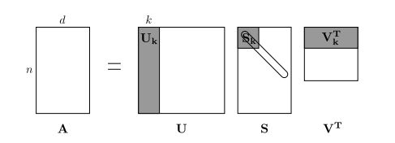

This reduced-dimensionality co-occurrence representation preserves semantic relationships between words, e.g. *doctor* and *hospital* will be closer than *doctor* and *dog*.

**If you are not friendly to SVD:** you can refer to [this comprehensive tutorial](https://davetang.org/file/Singular_Value_Decomposition_Tutorial.pdf) or these lecture notes ([1](https://web.stanford.edu/class/cs168/l/l7.pdf), [2](http://theory.stanford.edu/~tim/s15/l/l8.pdf), [3](https://web.stanford.edu/class/cs168/l/l9.pdf) ) of Stanford CS168. While these materials give a great introduction to PCA/SVD, you do not have to understand all of these materials for this assignment or this class.

## Plotting Co-Occurrence Word Embeddings

Here, we will be using the Reuters (business and financial news) corpus. If you haven't run the import cell above, please run it now (click it and press SHIFT-RETURN). The corpus consists of 10,788 news documents totaling 1.3 million words. These documents span 90 categories and are split into train and test. For more details, please see [this](https://www.nltk.org/book/ch02.html). We provide a `read_corpus` function below that pulls out only articles from the "crude" (i.e. news articles about oil, gas, etc.) category. The function also adds `<START>` and `<END>` tokens to each of the documents, and lowercases words. You do not have to perform any other kind of pre-processing.

```python
START_TOKEN = '<START>'
END_TOKEN = '<END>'

def read_corpus(category="crude"):
    """ Read files from the specified Reuter's category.
        Params:
            category (string): category name
        Return:
            list of lists, with words from each of the processed files
    """
    files = reuters.fileids(category)
    return [[START_TOKEN] + [w.lower() for w in list(reuters.words(f))] + [END_TOKEN] for f in files]
```

Let's have a look what these documents are like....

```python
reuters_corpus = read_corpus()
pprint.pprint(reuters_corpus[:3], compact=True, width=100)
```

```
[['<START>', 'japan', 'to', 'revise', 'long', '-', 'term', 'energy', 'demand', 'downwards', 'the',
  'ministry', 'of', 'international', 'trade', 'and', 'industry', '(', 'miti', ')', 'will', 'revise',
  'its', 'long', '-', 'term', 'energy', 'supply', '/', 'demand', 'outlook', 'by', 'august', 'to',
  'meet', 'a', 'forecast', 'downtrend', 'in', 'japanese', 'energy', 'demand', ',', 'ministry',
  'officials', 'said', '.', 'miti', 'is', 'expected', 'to', 'lower', 'the', 'projection', 'for',
  'primary', 'energy', 'supplies', 'in', 'the', 'year', '2000', 'to', '550', 'mln', 'kilolitres',
  '(', 'kl', ')', 'from', '600', 'mln', ',', 'they', 'said', '.', 'the', 'decision', 'follows',
  'the', 'emergence', 'of', 'structural', 'changes', 'in', 'japanese', 'industry', 'following',
  'the', 'rise', 'in', 'the', 'value', 'of', 'the', 'yen', 'and', 'a', 'decline', 'in', 'domestic',
  'electric', 'power', 'demand', '.', 'miti', 'is', 'planning', 'to', 'work', 'out', 'a', 'revised',
  'energy', 'supply', '/', 'demand', 'outlook', 'through', 'deliberations', 'of', 'committee',
  'meetings', 'of', 'the', 'agency', 'of', 'natural', 'resources', 'and', 'energy', ',', 'the',
  'officials', 'said', '.', 'they', 'said', 'miti', 'will', 'also', 'review', 'the', 'breakdown',
  'of', 'energy', 'supply', 'sources', ',', 'including', 'oil', ',', 'nuclear', ',', 'coal', 'and',
  'natural', 'gas', '.', 'nuclear', 'energy', 'provided', 'the', 'bulk', 'of', 'japan', "'", 's',
  'electric', 'power', 'in', 'the', 'fiscal', 'year', 'ended', 'march', '31', ',', 'supplying',
  'an', 'estimated', '27', 'pct', 'on', 'a', 'kilowatt', '/', 'hour', 'basis', ',', 'followed',
  'by', 'oil', '(', '23', 'pct', ')', 'and', 'liquefied', 'natural', 'gas', '(', '21', 'pct', '),',
  'they', 'noted', '.', '<END>'],
 ['<START>', 'energy', '/', 'u', '.', 's', '.', 'petrochemical', 'industry', 'cheap', 'oil',
  'feedstocks', ',', 'the', 'weakened', 'u', '.', 's', '.', 'dollar', 'and', 'a', 'plant',
  'utilization', 'rate', 'approaching', '90', 'pct', 'will', 'propel', 'the', 'streamlined', 'u',
  '.', 's', '.', 'petrochemical', 'industry', 'to', 'record', 'profits', 'this', 'year', ',',
  'with', 'growth', 'expected', 'through', 'at', 'least', '1990', ',', 'major', 'company',
  'executives', 'predicted', '.', 'this', 'bullish', 'outlook', 'for', 'chemical', 'manufacturing',
  'and', 'an', 'industrywide', 'move', 'to', 'shed', 'unrelated', 'businesses', 'has', 'prompted',
  'gaf', 'corp', '&', 'lt', ';', 'gaf', '>,', 'privately', '-', 'held', 'cain', 'chemical', 'inc',
  ',', 'and', 'other', 'firms', 'to', 'aggressively', 'seek', 'acquisitions', 'of', 'petrochemical',
  'plants', '.', 'oil', 'companies', 'such', 'as', 'ashland', 'oil', 'inc', '&', 'lt', ';', 'ash',
  '>,', 'the', 'kentucky', '-', 'based', 'oil', 'refiner', 'and', 'marketer', ',', 'are', 'also',
  'shopping', 'for', 'money', '-', 'making', 'petrochemical', 'businesses', 'to', 'buy', '.', '"',
  'i', 'see', 'us', 'poised', 'at', 'the', 'threshold', 'of', 'a', 'golden', 'period', ',"', 'said',
  'paul', 'oreffice', ',', 'chairman', 'of', 'giant', 'dow', 'chemical', 'co', '&', 'lt', ';',
  'dow', '>,', 'adding', ',', '"', 'there', "'", 's', 'no', 'major', 'plant', 'capacity', 'being',
  'added', 'around', 'the', 'world', 'now', '.', 'the', 'whole', 'game', 'is', 'bringing', 'out',
  'new', 'products', 'and', 'improving', 'the', 'old', 'ones', '."', 'analysts', 'say', 'the',
  'chemical', 'industry', "'", 's', 'biggest', 'customers', ',', 'automobile', 'manufacturers',
  'and', 'home', 'builders', 'that', 'use', 'a', 'lot', 'of', 'paints', 'and', 'plastics', ',',
  'are', 'expected', 'to', 'buy', 'quantities', 'this', 'year', '.', 'u', '.', 's', '.',
  'petrochemical', 'plants', 'are', 'currently', 'operating', 'at', 'about', '90', 'pct',
```

[output cut: 75 more lines]

```
  ',', 'economy', 'and', 'other', 'rights', 'of', 'both', 'countries', '.', '"', 'as', 'the',
  'issue', 'is', 'basicly', 'political', ',', 'a', 'solution', 'can', 'only', 'be', 'found', 'by',
  'bilateral', 'negotiations', ',"', 'the', 'statement', 'said', '.', 'greece', 'has', 'repeatedly',
  'said', 'the', 'issue', 'was', 'legal', 'and', 'could', 'be', 'solved', 'at', 'the',
  'international', 'court', 'of', 'justice', '.', 'the', 'two', 'countries', 'approached', 'armed',
  'confrontation', 'last', 'month', 'after', 'greece', 'announced', 'it', 'planned', 'oil',
  'exploration', 'work', 'in', 'the', 'aegean', 'and', 'turkey', 'said', 'it', 'would', 'also',
  'search', 'for', 'oil', '.', 'a', 'face', '-', 'off', 'was', 'averted', 'when', 'turkey',
  'confined', 'its', 'research', 'to', 'territorrial', 'waters', '.', '"', 'the', 'latest',
  'crises', 'created', 'an', 'historic', 'opportunity', 'to', 'solve', 'the', 'disputes', 'between',
  'the', 'two', 'countries', ',"', 'the', 'foreign', 'ministry', 'statement', 'said', '.', 'turkey',
  "'", 's', 'ambassador', 'in', 'athens', ',', 'nazmi', 'akiman', ',', 'was', 'due', 'to', 'meet',
  'prime', 'minister', 'andreas', 'papandreou', 'today', 'for', 'the', 'greek', 'reply', 'to', 'a',
  'message', 'sent', 'last', 'week', 'by', 'turkish', 'prime', 'minister', 'turgut', 'ozal', '.',
  'the', 'contents', 'of', 'the', 'message', 'were', 'not', 'disclosed', '.', '<END>']]
```

## Question 1.1: Implement `distinct_words` [code] (2 points)

Write a method to work out the distinct words (word types) that occur in the corpus. You can do this with for loops, but it's more efficient to do it with Python list comprehensions. In particular, [this](https://coderwall.com/p/rcmaea/flatten-a-list-of-lists-in-one-line-in-python) may be useful to flatten a list of lists. If you're not familiar with Python list comprehensions in general, here's [more information](https://python-3-patterns-idioms-test.readthedocs.io/en/latest/Comprehensions.html).

Your returned corpus_words should be sorted. You can use python's sorted function for this.

You may find it useful to use [Python sets](https://www.w3schools.com/python/python_sets.asp) to remove duplicate words.

```python
def distinct_words(corpus):
    """ Determine a list of distinct words for the corpus.
        Params:
            corpus (list of list of strings): corpus of documents
        Return:
            corpus_words (list of strings): sorted list of distinct words across the corpus
            num_corpus_words (integer): number of distinct words across the corpus
    """
    corpus_words = []
    num_corpus_words = -1

    # ------------------
    # Write your implementation here.
    flattened_corpus = [word for sentence in corpus for word in sentence]

    # ✅ 2. 중복 제거 후 정렬
    corpus_words = sorted(set(flattened_corpus))

    # ✅ 3. 고유한 단어 개수 계산
    num_corpus_words = len(corpus_words)


    # ------------------

    return corpus_words, num_corpus_words
```

Run below for sanity check - note that this is not an exhaustive check for correctness.

```python
# Define toy corpus
test_corpus = ["{} All that glitters isn't gold {}".format(START_TOKEN, END_TOKEN).split(" "), "{} All's well that ends well {}".format(START_TOKEN, END_TOKEN).split(" ")]
test_corpus_words, num_corpus_words = distinct_words(test_corpus)

# Correct answers
ans_test_corpus_words = sorted([START_TOKEN, "All", "ends", "that", "gold", "All's", "glitters", "isn't", "well", END_TOKEN])
ans_num_corpus_words = len(ans_test_corpus_words)

# Test correct number of words
assert(num_corpus_words == ans_num_corpus_words), "Incorrect number of distinct words. Correct: {}. Yours: {}".format(ans_num_corpus_words, num_corpus_words)

# Test correct words
assert (test_corpus_words == ans_test_corpus_words), "Incorrect corpus_words.\nCorrect: {}\nYours:   {}".format(str(ans_test_corpus_words), str(test_corpus_words))

# Print Success
print ("-" * 80)
print("Passed All Tests!")
print ("-" * 80)
```

```
--------------------------------------------------------------------------------
Passed All Tests!
--------------------------------------------------------------------------------
```

## Question 1.2: Implement `compute_co_occurrence_matrix` [code] (3 points)

Write a method that constructs a co-occurrence matrix for a certain window-size $n$ (with a default of 4), considering words $n$ before and $n$ after the word in the center of the window. Here, we start to use `numpy (np)` to represent vectors, matrices, and tensors. If you're not familiar with NumPy, there's a NumPy tutorial in the second half of this [Stanford cs231n Python NumPy tutorial](https://cs231n.github.io/python-numpy-tutorial/).

```python
def compute_co_occurrence_matrix(corpus, window_size=4):
    """ Compute co-occurrence matrix for the given corpus and window_size (default of 4).

        Note: Each word in a document should be at the center of a window. Words near edges will have a smaller
              number of co-occurring words.

              For example, if we take the document "<START> All that glitters is not gold <END>" with window size of 4,
              "All" will co-occur with "<START>", "that", "glitters", "is", and "not".

        Params:
            corpus (list of list of strings): corpus of documents
            window_size (int): size of context window
        Return:
            M (a symmetric numpy matrix of shape (number of unique words in the corpus , number of unique words in the corpus)):
                Co-occurence matrix of word counts.
                The ordering of the words in the rows/columns should be the same as the ordering of the words given by the distinct_words function.
            word2ind (dict): dictionary that maps word to index (i.e. row/column number) for matrix M.
    """
    words, num_words = distinct_words(corpus)
    M = None
    word2ind = {}

    # ------------------
    # Write your implementation here.
    i=0
    for v_c in words:
        #print(v_c,num_words)
        word2ind.update({v_c: i})
        i=i+1

    M=np.zeros((num_words,num_words))
    for str in corpus:
        for i_v_c in range(len(str)):
            for i_c_o in range(window_size):
                # print(i_c_o)
                if (i_v_c - i_c_o - 1 >= 0):
                    # print(str[i_v_c])
                    M[word2ind[str[i_v_c]]][word2ind[str[i_v_c - i_c_o - 1]]] = M[word2ind[str[i_v_c]]][word2ind[
                        str[i_v_c - i_c_o - 1]]] + 1
                if (i_v_c + i_c_o + 1 < len(str)):
                    # print(str[i_v_c])
                    M[word2ind[str[i_v_c]]][word2ind[str[i_v_c + i_c_o + 1]]] = M[word2ind[str[i_v_c]]][word2ind[
                        str[i_v_c + i_c_o + 1]]] + 1
        print(word2ind)


    # ------------------

    return M, word2ind
```

Run below for sanity check - note that this is not an exhaustive check for correctness.

```python
# Define toy corpus and get student's co-occurrence matrix
test_corpus = ["{} All that glitters isn't gold {}".format(START_TOKEN, END_TOKEN).split(" "), "{} All's well that ends well {}".format(START_TOKEN, END_TOKEN).split(" ")]
M_test, word2ind_test = compute_co_occurrence_matrix(test_corpus, window_size=1)

# Correct M and word2ind
M_test_ans = np.array(
    [[0., 0., 0., 0., 0., 0., 1., 0., 0., 1.,],
     [0., 0., 1., 1., 0., 0., 0., 0., 0., 0.,],
     [0., 1., 0., 0., 0., 0., 0., 0., 1., 0.,],
     [0., 1., 0., 0., 0., 0., 0., 0., 0., 1.,],
     [0., 0., 0., 0., 0., 0., 0., 0., 1., 1.,],
     [0., 0., 0., 0., 0., 0., 0., 1., 1., 0.,],
     [1., 0., 0., 0., 0., 0., 0., 1., 0., 0.,],
     [0., 0., 0., 0., 0., 1., 1., 0., 0., 0.,],
     [0., 0., 1., 0., 1., 1., 0., 0., 0., 1.,],
     [1., 0., 0., 1., 1., 0., 0., 0., 1., 0.,]]
)
ans_test_corpus_words = sorted([START_TOKEN, "All", "ends", "that", "gold", "All's", "glitters", "isn't", "well", END_TOKEN])
word2ind_ans = dict(zip(ans_test_corpus_words, range(len(ans_test_corpus_words))))

# Test correct word2ind
assert (word2ind_ans == word2ind_test), "Your word2ind is incorrect:\nCorrect: {}\nYours: {}".format(word2ind_ans, word2ind_test)

# Test correct M shape
assert (M_test.shape == M_test_ans.shape), "M matrix has incorrect shape.\nCorrect: {}\nYours: {}".format(M_test.shape, M_test_ans.shape)

# Test correct M values
for w1 in word2ind_ans.keys():
    idx1 = word2ind_ans[w1]
    for w2 in word2ind_ans.keys():
        idx2 = word2ind_ans[w2]
        student = M_test[idx1, idx2]
        correct = M_test_ans[idx1, idx2]
        if student != correct:
            print("Correct M:")
            print(M_test_ans)
            print("Your M: ")
            print(M_test)
            raise AssertionError("Incorrect count at index ({}, {})=({}, {}) in matrix M. Yours has {} but should have {}.".format(idx1, idx2, w1, w2, student, correct))

# Print Success
print ("-" * 80)
print("Passed All Tests!")
print ("-" * 80)
```

```
{'<END>': 0, '<START>': 1, 'All': 2, "All's": 3, 'ends': 4, 'glitters': 5, 'gold': 6, "isn't": 7, 'that': 8, 'well': 9}
{'<END>': 0, '<START>': 1, 'All': 2, "All's": 3, 'ends': 4, 'glitters': 5, 'gold': 6, "isn't": 7, 'that': 8, 'well': 9}
--------------------------------------------------------------------------------
Passed All Tests!
--------------------------------------------------------------------------------
```

## Question 1.3: Implement `reduce_to_k_dim` [code] (1 point)

Construct a method that performs dimensionality reduction on the matrix to produce k-dimensional embeddings. Use SVD to take the top k components and produce a new matrix of k-dimensional embeddings.

**Note:** Please use [sklearn.decomposition.TruncatedSVD](https://scikit-learn.org/stable/modules/generated/sklearn.decomposition.TruncatedSVD.html) for SVD. While there are numbers of implementation of SVD (e.g. numpy, scipy, ...), it is challenging to apply full SVD to large corpora due to its high asymptotic complexity. Here we only need top $k$ vector components for relative small $k$, which is the case called Truncated SVD, and some iterative algorithms for this scale reasonably. The above implementation by sklean is an efficient randomized algorithm for calculating large-scale Truncated SVD.

```python
def reduce_to_k_dim(M, k=2):
    """ Reduce a co-occurence count matrix of dimensionality (num_corpus_words, num_corpus_words)
        to a matrix of dimensionality (num_corpus_words, k) using the following SVD function from Scikit-Learn:
            - http://scikit-learn.org/stable/modules/generated/sklearn.decomposition.TruncatedSVD.html

        Params:
            M (numpy matrix of shape (number of unique words in the corpus , number of unique words in the corpus)): co-occurence matrix of word counts
            k (int): embedding size of each word after dimension reduction
        Return:
            M_reduced (numpy matrix of shape (number of corpus words, k)): matrix of k-dimensioal word embeddings.
                    In terms of the SVD from math class, this actually returns U * S
    """
    n_iters = 10     # Use this parameter in your call to `TruncatedSVD`
    M_reduced = None
    print("Running Truncated SVD over %i words..." % (M.shape[0]))

    # ------------------
    # Write your implementation here.
    pca=PCA(n_components=k)
    M_reduced = pca.fit_transform(M)

    # ------------------

    print("Done.")
    return M_reduced
```

Run below for sanity check - note that the code below only check shapes.

```python
# Define toy corpus and run student code
test_corpus = ["{} All that glitters isn't gold {}".format(START_TOKEN, END_TOKEN).split(" "), "{} All's well that ends well {}".format(START_TOKEN, END_TOKEN).split(" ")]
M_test, word2ind_test = compute_co_occurrence_matrix(test_corpus, window_size=1)
M_test_reduced = reduce_to_k_dim(M_test, k=2)

# Test proper dimensions
assert (M_test_reduced.shape[0] == 10), "M_reduced has {} rows; should have {}".format(M_test_reduced.shape[0], 10)
assert (M_test_reduced.shape[1] == 2), "M_reduced has {} columns; should have {}".format(M_test_reduced.shape[1], 2)

# Print Success
print ("-" * 80)
print("Passed All Tests!")
print ("-" * 80)
```

```
{'<END>': 0, '<START>': 1, 'All': 2, "All's": 3, 'ends': 4, 'glitters': 5, 'gold': 6, "isn't": 7, 'that': 8, 'well': 9}
{'<END>': 0, '<START>': 1, 'All': 2, "All's": 3, 'ends': 4, 'glitters': 5, 'gold': 6, "isn't": 7, 'that': 8, 'well': 9}
Running Truncated SVD over 10 words...
Done.
--------------------------------------------------------------------------------
Passed All Tests!
--------------------------------------------------------------------------------
```

## Question 1.4: Implement `plot_embeddings` [code] (1 point)

Here you will write a function to plot a set of 2D vectors in 2D space. For graphs, we will use Matplotlib (`plt`).

For this example, you may find it useful to adapt [this code](http://web.archive.org/web/20190924160434/https://www.pythonmembers.club/2018/05/08/matplotlib-scatter-plot-annotate-set-text-at-label-each-point/). In the future, a good way to make a plot is to look at the [Matplotlib gallery](https://matplotlib.org/stable/gallery/index.html), find a plot that looks somewhat like what you want, and adapt the code they give.

```python
def plot_embeddings(M_reduced, word2ind, words):
    """ Plot in a scatterplot the embeddings of the words specified in the list "words".
        NOTE: do not plot all the words listed in M_reduced / word2ind.
        Include a label next to each point.

        Params:
            M_reduced (numpy matrix of shape (number of unique words in the corpus , 2)): matrix of 2-dimensioal word embeddings
            word2ind (dict): dictionary that maps word to indices for matrix M
            words (list of strings): words whose embeddings we want to visualize
    """

    # ------------------
    # Write your implementation here.
    indices = [word2ind[word] for word in words]
    x_coords = [M_reduced[index, 0] for index in indices]
    y_coords = [M_reduced[index, 1] for index in indices]

    for i, word in enumerate(words):
        x = x_coords[i]
        y = y_coords[i]
        plt.scatter(x, y, marker='x', color='red')
        plt.text(x, y, word, fontsize=9)
    plt.show()

    # ------------------
```

Run below for sanity check - the plot produced should look like the "test solution plot" depicted below.

```
--------------------------------------------------------------------------------
Outputted Plot:
```

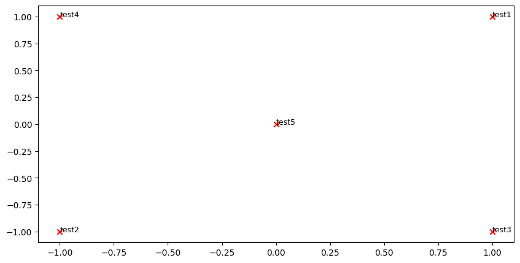

```python
print ("-" * 80)
print ("Outputted Plot:")

M_reduced_plot_test = np.array([[1, 1], [-1, -1], [1, -1], [-1, 1], [0, 0]])
word2ind_plot_test = {'test1': 0, 'test2': 1, 'test3': 2, 'test4': 3, 'test5': 4}
words = ['test1', 'test2', 'test3', 'test4', 'test5']
plot_embeddings(M_reduced_plot_test, word2ind_plot_test, words)

print ("-" * 80)
```

**Test Plot Solution**

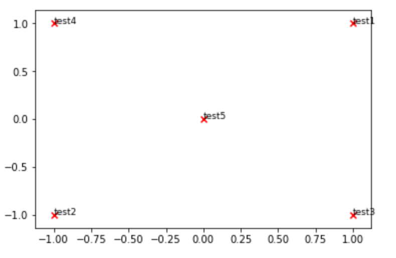

## Question 1.5: Co-Occurrence Plot Analysis [written] (3 points)

**Note:** The line of code below that does the normalizing uses the NumPy concept of broadcasting. If you don't know about broadcasting, check out [Computation on Arrays: Broadcasting by Jake VanderPlas](https://jakevdp.github.io/PythonDataScienceHandbook/02.05-computation-on-arrays-broadcasting.html).

Run the below cell to produce the plot. It'll probably take a few seconds to run. What clusters together in 2-dimensional embedding space? What doesn't cluster together that you might think should have? **Note:** "bpd" stands for "barrels per day" and is a commonly used abbreviation in crude oil topic articles.

```python
# -----------------------------
# Run This Cell to Produce Your Plot
# ------------------------------
reuters_corpus = read_corpus()
M_co_occurrence, word2ind_co_occurrence = compute_co_occurrence_matrix(reuters_corpus)
M_reduced_co_occurrence = reduce_to_k_dim(M_co_occurrence, k=2)

# Rescale (normalize) the rows to make them each of unit-length
M_lengths = np.linalg.norm(M_reduced_co_occurrence, axis=1)
M_normalized = M_reduced_co_occurrence / M_lengths[:, np.newaxis] # broadcasting

words = ['barrels', 'bpd', 'ecuador', 'energy', 'industry', 'kuwait', 'oil', 'output', 'petroleum', 'iraq']

plot_embeddings(M_normalized, word2ind_co_occurrence, words)
```

```
Output hidden; open in https://colab.research.google.com to view.
```

**Write your answer here. You can write in either Korean or English.**

Oil-related terms cluster together: "oil", "petroleum", "energy", "industry". Country-related terms cluster together: "kuwait", "iraq", "ecuador". Production-related terms cluster together: "barrels", "output", "bpd". (But, "bpd" appears slightly separated from "barrels" and "output".)

# Part 2: Prediction-Based Word Vectors (15 points)

As discussed in class, more recently prediction-based word vectors have demonstrated better performance, such as word2vec and GloVe (which also utilizes the benefit of counts). Here, we shall explore the embeddings produced by GloVe. Please revisit the class notes and lecture slides for more details on the word2vec and GloVe algorithms. If you're feeling adventurous, challenge yourself and try reading [GloVe's original paper](https://nlp.stanford.edu/pubs/glove.pdf).

Then run the following cells to load the GloVe vectors into memory. **Note:** If this is your first time to run these cells, i.e. download the embedding model, it will take a couple minutes to run. If you've run these cells before, rerunning them will load the model without redownloading it, which will take about 1 to 2 minutes.

```python
def load_embedding_model():
    """ Load GloVe Vectors
        Return:
            wv_from_bin: All 400000 embeddings, each lengh 200
    """
    import gensim.downloader as api
    wv_from_bin = api.load("glove-wiki-gigaword-200")
    # print("Loaded vocab size %i" % len(wv_from_bin.vocab.keys()))
    print("Loaded vocab size %i" % len(wv_from_bin.key_to_index))  # 수정된 부분
    return wv_from_bin
wv_from_bin = load_embedding_model()
```

```
Loaded vocab size 400000
```

## **Note: If you are receiving a "reset by peer" error, rerun the cell to restart the download.**

gensim 4.0.0 버전부터 wv_from_bin.vocab 속성이 제거되어서 대신 .key_to_index 속성을 사용해야 될것 같습니다!

## Reducing dimensionality of Word Embeddings

Let's directly compare the GloVe embeddings to those of the co-occurrence matrix. In order to avoid running out of memory, we will work with a sample of 10000 GloVe vectors instead. Run the following cells to:

1. Put 10000 Glove vectors into a matrix $M$
2. Run `reduce_to_k_dim` (your Truncated SVD function) to reduce the vectors from 200-dimensional to 2-dimensional.

```python
def get_matrix_of_vectors(wv_from_bin, required_words=['barrels', 'bpd', 'ecuador', 'energy', 'industry', 'kuwait', 'oil', 'output', 'petroleum', 'iraq']):
    """ Put the GloVe vectors into a matrix M.
        Param:
            wv_from_bin: KeyedVectors object; the 400000 GloVe vectors loaded from file
        Return:
            M: numpy matrix shape (num words, 200) containing the vectors
            word2ind: dictionary mapping each word to its row number in M
    """
    import random
    # words = list(wv_from_bin.vocab.keys())
    words = list(wv_from_bin.key_to_index.keys())  # gensim 4.x 대응
    print("Shuffling words ...")
    random.seed(224)
    random.shuffle(words)
    words = words[:10000]
    print("Putting %i words into word2ind and matrix M..." % len(words))
    word2ind = {}
    M = []
    curInd = 0
    for w in words:
        try:
            M.append(wv_from_bin.word_vec(w))
            word2ind[w] = curInd
            curInd += 1
        except KeyError:
            continue
    for w in required_words:
        if w in words:
            continue
        try:
            M.append(wv_from_bin.word_vec(w))
            word2ind[w] = curInd
            curInd += 1
        except KeyError:
            continue
    M = np.stack(M)
    print("Done.")
    return M, word2ind
```

Run the cell below to reduce 200-dimensional word embeddings to $k$ dimensions. This should be quick to run.

```python
M, word2ind = get_matrix_of_vectors(wv_from_bin)
M_reduced = reduce_to_k_dim(M, k=2)

# Rescale (normalize) the rows to make them each of unit-length
M_lengths = np.linalg.norm(M_reduced, axis=1)
M_reduced_normalized = M_reduced / M_lengths[:, np.newaxis] # broadcasting
```

```
Shuffling words ...
Putting 10000 words into word2ind and matrix M...
Done.
Running Truncated SVD over 10010 words...
Done.
```

## Question 2.1: GloVe Plot Analysis [written] (3 points)

Run the cell below to plot the 2D GloVe embeddings for `['barrels', 'bpd', 'ecuador', 'energy', 'industry', 'kuwait', 'oil', 'output', 'petroleum', 'iraq']`.

What clusters together in 2-dimensional embedding space? What doesn't cluster together that you think should have? How is the plot different from the one generated earlier from the co-occurrence matrix? What is a possible cause for the difference?

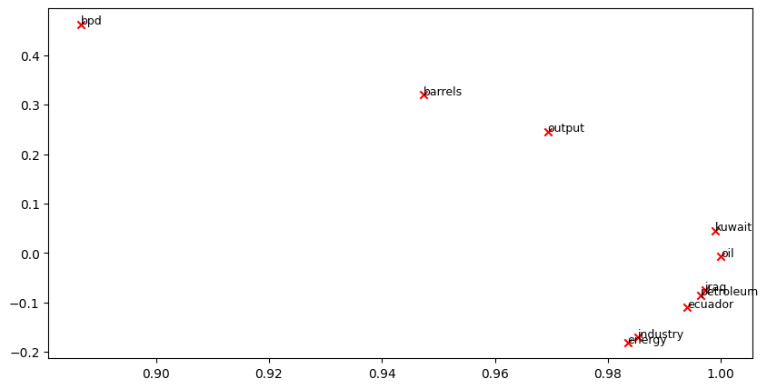

```python
words = ['barrels', 'bpd', 'ecuador', 'energy', 'industry', 'kuwait', 'oil', 'output', 'petroleum', 'iraq']
plot_embeddings(M_reduced_normalized, word2ind, words)
```

**Write your answer here. You can write in either Korean or English.**

1번: kuwait, oil, iraq, petroleum, ecuador, energy, industry가 밀집하여 석유 및 에너지 관련 의미 군집을 형성함.

2번: bpd가 barrels, output과 멀리 떨어져 있어, 의미적으로 가깝다고 예상한 관계가 잘 반영되지 않음.

3번: 이전의 공기(co-occurrence) 기반 임베딩은 단순히 출현 빈도에 따라 군집이 형성된 반면, 이번의 GloVe는 전역적 문맥과 의미를 더 깊게 반영해 좀 더 의미적 군집을 형성함.

4번: 단순 빈도가 아닌 전역적 맥락과 의미를 중시하는 GloVe 임베딩의 특성 때문.

### Cosine Similarity

Now that we have word vectors, we need a way to quantify the similarity between individual words, according to these vectors. One such metric is cosine-similarity. We will be using this to find words that are "close" and "far" from one another.

We can think of $n$-dimensional vectors as points in $n$-dimensional space. If we take this perspective [$L^1$](https://mathworld.wolfram.com/L1-Norm.html) and [$L^2$](https://mathworld.wolfram.com/L2-Norm.html) Distances help quantify the amount of space "we must travel" to get between these two points. Another approach is to examine the angle between two vectors. From trigonometry we know that:

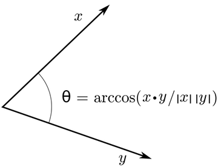

Instead of computing the actual angle, we can leave the similarity in terms of similarity$=\cos(\theta)$. Formally, [the Cosine Similarity](https://en.wikipedia.org/wiki/Cosine_similarity) $s$ between two vectors $p$ and $q$ is defined as:

$$s=\frac{p\cdot q}{\lVert p \rVert\lVert q \rVert},$$ where $s\in [-1, 1]$.

## Question 2.2: Words with Multiple Meanings [code + written] (1.5 points)

Polysemes and homonyms are words that have more than one meaning (see [this wiki](https://en.wikipedia.org/wiki/Polysemy) for details). Find a word with **at least two different meanings** such that the top-10 most similar words (according to cosine similarity) contain related words from **both** meanings. For example, "leaves" has both "go_away" and "a_structure_of_a_plant" meaning in the top 10, and "scoop" has both "handed_waffle_cone" and "lowdown". You will probably need to try several polysemous or homonymic words before you find one.

Please state the word you discover and the multiple meanings that occur in the top 10. Why do you think many of the polysemous or homonymic words you tried didn't work (i.e. the top-10 most similar words only contain one of the meanings of the words)?

Note: You should use the `wv_from_bin.most_similar(word)` function to get the top 10 similar words. This function ranks all other words in the vocabulary with respect to their cosine similarity to the given word. For further assistance, please check [the GenSim documentation](https://radimrehurek.com/gensim/models/keyedvectors.html#gensim.models.keyedvectors.FastTextKeyedVectors.most_similar).

```python
print('10 Similar words to "leaves":', wv_from_bin.most_similar('leaves'))
# ------------------
# Write your implementation here.
print(wv_from_bin.most_similar('mouse'))

# ------------------
```

```
10 Similar words to "leaves": [('ends', 0.6128067970275879), ('leaf', 0.6027014255523682), ('stems', 0.5998532176017761), ('takes', 0.5902854204177856), ('leaving', 0.5761634707450867), ('grows', 0.5663397312164307), ('flowers', 0.5600922107696533), ('turns', 0.5536050796508789), ('leave', 0.5496848…
[('mice', 0.6580958962440491), ('keyboard', 0.5548278093338013), ('rat', 0.5433949828147888), ('rabbit', 0.5192376971244812), ('cat', 0.5077415704727173), ('cursor', 0.5058691501617432), ('trackball', 0.5048902630805969), ('joystick', 0.49841049313545227), ('mickey', 0.47242844104766846), ('clicks',…
```

**Write your answer here. You can write in either Korean or English.**

대부분의 다의어(polysemous/homonymic)는 단어 임베딩에서 자주 사용되는 한 가지 주요 의미가 다른 의미들보다 압도적으로 빈번하기 때문입니다. 따라서 Word Embedding 모델은 주로 가장 자주 쓰이는 의미를 중심으로 단어의 임베딩을 형성하고, 덜 빈번한 다른 의미는 밀려나게 됩니다.

즉, 빈도수의 차이가 크면 주요 의미 하나가 다른 의미들을 압도하여, 여러 의미가 함께 나타나기 어렵습니다.

## Question 2.3: Synonyms & Antonyms [code + written] (2 points)

When considering Cosine Similarity, it's often more convenient to think of Cosine Distance, which is simply $1 - \text{Cosine Similarity}$.

Find three words $(w_1,w_2,w_3)$ where $w_1$ and $w_2$ are synonyms and $w_1$ and $w_3$ are antonyms, but Cosine Distance $(w_1,w_3)< \text{Cosine Distance} (w_1,w_2)$ .

As an example, $w_1 =``\text{happy}"$ is closer to $w_3 =``\text{sad}"$ than to $w_2 =``\text{cheerful}"$. Please find a different example that satisfies the above. Once you have found your example, please give a possible explanation for why this counter-intuitive result may have happened.

You should use the the `wv_from_bin.distance(w1, w2)` function here in order to compute the cosine distance between two words. Please see [the GenSim documentation](https://radimrehurek.com/gensim/models/keyedvectors.html#gensim.models.keyedvectors.FastTextKeyedVectors.distance) for further assistance.

```python
print('Cosine distance between "happy" and "sad":', wv_from_bin.distance('happy', 'sad'))
print('Cosine distance between "happy" and "cheerful":', wv_from_bin.distance('happy', 'cheerful'))
# ------------------
# Write your implementation here.
w1 = "fun"
w2 = "interesting"
w3 = "boring"
w1_w2_dist = wv_from_bin.distance(w1, w2)
w1_w3_dist = wv_from_bin.distance(w1, w3)

print("Synonyms {}, {} have cosine distance: {}".format(w1, w2, w1_w2_dist))
print("Antonyms {}, {} have cosine distance: {}".format(w1, w3, w1_w3_dist))

# ------------------
```

```
Cosine distance between "happy" and "sad": 0.4040136933326721
Cosine distance between "happy" and "cheerful": 0.5172466933727264
Synonyms fun, interesting have cosine distance: 0.39161139726638794
Antonyms fun, boring have cosine distance: 0.4416987895965576
```

**Write your answer here. You can write in either Korean or English.**

## Question 2.4: Analogies with Word Vectors [written] (1.5 points)

Word vectors have been shown to *sometimes* exhibit the ability to solve analogies.

As an example, for the analogy "man : king :: woman : $x$" (read: man is to king as woman is to $x$), what is $x$?

In the cell below, we show you how to use word vectors to find $x$ using the `most_similar` function from the [GenSim documentation](https://radimrehurek.com/gensim/models/keyedvectors.html#gensim.models.keyedvectors.KeyedVectors.most_similar). The function finds words that are most similar to the words in the `positive` list and most dissimilar from the words in the `negative` list (while omitting the input words, which are often the most similar; see [this paper](https://aclanthology.org/N18-2039.pdf) for more details). The answer to the analogy will have the highest cosine similarity (largest returned numerical value).

```python
# Run this cell to answer the analogy -- man : king :: woman : x
print(wv_from_bin.most_similar(positive=['woman', 'king'], negative=['man']))
```

```
[('queen', 0.6978678107261658), ('princess', 0.6081745028495789), ('monarch', 0.5889754891395569), ('throne', 0.5775108933448792), ('prince', 0.5750998258590698), ('elizabeth', 0.5463595986366272), ('daughter', 0.5399126410484314), ('kingdom', 0.5318052768707275), ('mother', 0.5168544054031372), ('c…
```

Let $m$ , $k$ , $w$ , and $x$ denote the word vectors for `man`, `king`, `woman`, and the answer, respectively. Using only vectors $m$ , $k$ , $w$ , and the vector arithmetic operators $+$ and $−$ in your answer, what is the expression in which we are maximizing cosine similarity with $x$ ?

**Hint:** Recall that word vectors are simply multi-dimensional vectors that represent a word. It might help to draw out a 2D example using arbitrary locations of each vector. Where would `man` and `woman` lie in the coordinate plane relative to `king` and the answer?

**Write your answer here. You can use $ $ signs around the letter to write mathematical symbols and equations.**

x는 아래 벡터 표현과의 코사인 유사도가 가장 큰 단어입니다.

𝑥≈(king−man+woman)

즉,"king"에서 "man"을 빼고, "woman"을 더한 벡터와 가장 유사한 단어가 정답이 됩니다.

## Question 2.5: Finding Analogies [code + written] (1.5 points)

Similar to the example in the cell above in question 2.4, find an example of analogy that holds according to these vectors (i.e. the intended word is ranked top). In your solution please state the full analogy in the form "$x:y :: a:b$". If you believe the analogy is complicated, explain why the analogy holds in one or two sentences.

**Note:** You may have to try many analogies to find one that works!

```python
# ------------------
# Write your implementation here.
print(wv_from_bin.most_similar(positive=['korea', 'paris'], negative=['seoul']))
print(wv_from_bin.most_similar(positive=['korea', 'american'], negative=['american']))

# ------------------
```

```
[('france', 0.8202266693115234), ('french', 0.6520258784294128), ('prohertrib', 0.6464229226112366), ('europe', 0.6045393943786621), ('spain', 0.528137743473053), ('italy', 0.5159087181091309), ('britain', 0.5143422484397888), ('belgium', 0.5083732604980469), (',', 0.5068506598472595), ('germany', 0…
[('korean', 0.7994203567504883), ('pyongyang', 0.7778059840202332), ('dprk', 0.7498499751091003), ('seoul', 0.7380223274230957), ('koreans', 0.7019164562225342), ('south', 0.6780501008033752), ('north', 0.6694514155387878), ('japan', 0.6623660326004028), ('kim', 0.6211698055267334), ('china', 0.6147…
```

**Write your answer here. You can write in either Korean or English.**

첫 번째 analogy: paris : france :: seoul : korea

## Question 2.6: Incorrect Analogy [code + written] (1.5 points)

Find an example of analogy that does not hold according to these vectors. In your solution, state the intended analogy in the form "$x:y :: a:b$", and state the (incorrect) value of $b$ according to the word vectors.

```python
# ------------------
# Write your implementation here.
print(wv_from_bin.most_similar(positive=['brother', 'prince'], negative=['princess']))

# ------------------
```

```
[('son', 0.7171408534049988), ('nephew', 0.7105350494384766), ('uncle', 0.6716316938400269), ('father', 0.6675162315368652), ('cousin', 0.6243720650672913), ('grandson', 0.5928134322166443), ('brother-in-law', 0.5875222682952881), ('sons', 0.5859827995300293), ('grandfather', 0.5678690075874329), ('…
```

**Write your answer here. You can write in either Korean or English.**

실제 word vector 결과 (잘못된 결과): 가장 유사한 단어는 son으로 나타났습니다.

이유: 단어 벡터가 의미의 정확한 관계보다는 빈번히 같이 사용되는 문맥(가족 관련) 위주로 학습되었기 때문입니다.

## Question 2.7: Guided Analysis of Bias in Word Vectors [written] (1 point)

It's important to be cognizant of the biases (gender, race, sexual orientation etc.) implicit in our word embeddings. Bias can be dangerous because it can reinforce stereotypes through applications that employ these models.

Run the cell below, to examine (a) which terms are most similar to "woman" and "worker" and most dissimilar to "man", and (b) which terms are most similar to "man" and "worker" and most dissimilar to "woman". Point out the difference between the list of female-associated words and the list of male-associated words, and explain how it is reflecting gender bias.

```python
# Run this cell
# Here `positive` indicates the list of words to be similar to and `negative` indicates the list of words to be
# most dissimilar from.
pprint.pprint(wv_from_bin.most_similar(positive=['woman', 'worker'], negative=['man']))
print()
pprint.pprint(wv_from_bin.most_similar(positive=['man', 'worker'], negative=['woman']))
```

```
[('employee', 0.6375863552093506),
 ('workers', 0.6068920493125916),
 ('nurse', 0.5837947130203247),
 ('pregnant', 0.5363885164260864),
 ('mother', 0.5321308970451355),
 ('employer', 0.5127025842666626),
 ('teacher', 0.5099576711654663),
 ('child', 0.5096741318702698),
 ('homemaker', 0.5019454956054688),
 ('nurses', 0.4970572590827942)]

[('workers', 0.611325740814209),
 ('employee', 0.5983108878135681),
 ('working', 0.5615329742431641),
 ('laborer', 0.5442320108413696),
 ('unemployed', 0.536851704120636),
 ('job', 0.5278826355934143),
 ('work', 0.5223963856697083),
 ('mechanic', 0.5088937282562256),
 ('worked', 0.5054520964622498),
 ('factory', 0.4940454363822937)]
```

**Write your answer here. You can write in either Korean or English.**

제공된 코드 실행 결과를 보면, 단어 임베딩 모델이 "woman"과 "worker"를 긍정적으로 연관짓고 "man"을 부정적으로 연관지었을 때와, 반대로 "man"과 "worker"를 긍정적으로 연관짓고 "woman"을 부정적으로 연관지었을 때의 결과가 다르게 나타났습니다.

이러한 결과는 성별 고정관념이 반영된 것으로 볼 수 있으며, AI 모델이 사회적 편견을 학습할 수 있다는 점을 시사합니다. 이러한 편향이 유지될 경우, 성별에 따른 직업 차별이 강화될 위험이 있습니다.

## Question 2.8: Independent Analysis of Bias in Word Vectors [code + written] (1 point)

Use the `most_similar` function to find another case where some bias is exhibited by the vectors. Please briefly explain the example of bias that you discover.

```python
# ------------------
# Write your implementation here.
pprint.pprint(wv_from_bin.most_similar(positive=['man', 'good'], negative=['woman']))
print()
pprint.pprint(wv_from_bin.most_similar(positive=['woman', 'good'], negative=['man']))

# ------------------
```

```
[('better', 0.6887748837471008),
 ('really', 0.6642923951148987),
 ('always', 0.6557818651199341),
 ('things', 0.6545915007591248),
 ('we', 0.6536529660224915),
 ('way', 0.651599109172821),
 ('sure', 0.64736407995224),
 ('think', 0.6444875597953796),
 ('well', 0.6428843140602112),
 ('you', 0.640580415725708)]

[('really', 0.6510533094406128),
 ('she', 0.649827241897583),
 ('very', 0.6449405550956726),
 ('better', 0.6440967321395874),
 ('always', 0.642605185508728),
 ('pretty', 0.6323509216308594),
 ('sure', 0.6309526562690735),
 ('you', 0.6308726668357849),
 ('get', 0.6258790493011475),
 ('wonderful', 0.6197566390037537)]
```

**Write your answer here. You can write in either Korean or English.**

[man + good - woman] 결과는 일반적이고 중립적인 단어가 많습니다. (예: better, really, always, things, we 등)

[woman + good - man] 결과는 감성적이고 외모 관련 단어가 많습니다. (예: she, pretty, wonderful 등)

이러한 결과는 여성 관련 표현이 외모나 감정 중심으로 나타나는 성별 편향(gender bias)을 드러냅니다.

## Question 2.9: Thinking About Bias [written] (2 points)

Give one explanation of how bias gets into the word vectors. What is an experiment that you could do to test for or to measure this source of bias?

**Write your answer here. You can write in either Korean or English.**

편향 발생 원인: 단어 벡터는 대규모 텍스트 데이터를 기반으로 학습되므로, 데이터에 포함된 성별 편견과 같은 사회적 고정관념이 임베딩에 그대로 반영됩니다.

구체적인 실험 방법: 다음과 같은 실험을 수행할 수 있습니다.

남성 단어("man", "male", "he")와 여성 단어("woman", "female", "she") 각각에 대해 직업 관련 단어("doctor", "engineer", "nurse", "teacher" 등) 간의 코사인 유사도를 측정합니다. 남성 및 여성 단어 그룹과 각 직업 단어 간의 평균 유사도 차이를 구하여 성별과 직업의 연관성 정도를 정량화합니다. 이를 통해 특정 직업이 특정 성별과 얼마나 강하게 연관되는지 비교하여, 벡터가 지니고 있는 성별 편향을 구체적으로 확인할 수 있습니다. 이러한 과정을 통해 임베딩 내에 숨겨진 사회적 편견이나 고정관념을 객관적으로 측정할 수 있습니다.

#### Congratulations on finishing Assignment 1.

# Submission Instructions

1. Click File -> Save or 파일-> 저장 to save.
2. Run the code cell below. It requires to mount your Google Drive to VM, so authorize as instructed.
3. `.html` file will be automatically downloaded (allow the permission to download file if asked). Submit your `.html` file on Blackboard.

```python
from google.colab import drive, files
from requests import get
from urllib.parse import unquote

drive.mount('/mnt/')
filename = unquote(get('http://172.28.0.12:9000/api/sessions').json()[0]['name'])
filepath = f'/mnt/My Drive/Colab Notebooks/{filename}'
output_file = '/content/Assignment1_2020170984.html'

!jupyter nbconvert '{filepath}' --output '{output_file}'
files.download(output_file)
```

[output not shown]

[output not shown]

```python
import subprocess
import re

# 현재 Colab 환경에서 Jupyter 서버가 실행 중인 IP 주소 찾기
result = subprocess.run(["netstat", "-tuln"], capture_output=True, text=True)
matches = re.findall(r'172\.28\.\d+\.\d+', result.stdout)

if matches:
    colab_ip = matches[0]  # 가장 먼저 발견된 IP 사용
    print(f"✅ 현재 Colab Jupyter 서버 IP: {colab_ip}")
else:
    print("❌ 유효한 IP를 찾지 못했습니다.")
```

```
✅ 현재 Colab Jupyter 서버 IP: 172.28.0.12
```

```python
from google.colab import drive, files
from requests import get
from urllib.parse import unquote

# 1️⃣ 구글 드라이브 마운트
drive.mount('/mnt/', force_remount=True)

# 2️⃣ 현재 실행 중인 노트북 파일 이름 가져오기
try:
    filename = unquote(get('http://172.28.0.12:9000/api/sessions').json()[0]['name'])  # ✅ IP 자동 감지로 변경
except:
    print("❌ 현재 실행 중인 노트북 파일을 찾을 수 없습니다.")
    filename = None

if filename:
    # 3️⃣ 파일 경로 설정
    filepath = f'/mnt/MyDrive/Colab Notebooks/{filename}'  # ✅ "My Drive" → "MyDrive" 로 변경
    output_file = '/content/Assignment1_2020170984.html'

    # 4️⃣ Jupyter Notebook을 HTML로 변환 (올바른 변환 형식 추가)
    !jupyter nbconvert --to html '{filepath}' --output '{output_file}'

    # 5️⃣ 파일 존재 여부 확인 후 다운로드
    if os.path.exists(output_file):
        files.download(output_file)
        print("✅ 파일 다운로드 완료!")
    else:
        print("❌ 변환된 HTML 파일을 찾을 수 없습니다. 경로를 확인하세요.")
else:
    print("❌ 실행 중인 노트북을 찾을 수 없습니다.")
```

```
Mounted at /mnt/
[NbConvertApp] Converting notebook /mnt/MyDrive/Colab Notebooks/Assignment1_2020170984.ipynb to html
[NbConvertApp] WARNING | Alternative text is missing on 2 image(s).
[NbConvertApp] Writing 567804 bytes to /content/Assignment1_2020170984.html
```

[output not shown]